# HNB DigiMedia Map 2: Thematic Structure

What is Croatian Central Banking Coverage About?

Author

HNB DigiMedia Project

Published

January 28, 2026

# 1 Introduction

This document presents **Map 2: Thematic Structure** of the HNB DigiMedia project. The core question driving this analysis is: **What is Croatian central banking coverage about, and who specializes in what?**

We use topic modeling to discover the thematic landscape of the corpus and then examine how different actors specialize in particular topics. This analysis directly addresses hypotheses about the content structure of monetary policy coverage during Croatias historic transition to the euro.

## 1.1 Methodological Overview

**Topic modeling** is an unsupervised machine learning technique that discovers latent thematic patterns in large text corpora. Unlike manual content analysis, topic models can process thousands of documents and identify recurring themes without predefined categories.

We employ **Structural Topic Modeling (STM)**, an extension of Latent Dirichlet Allocation (LDA) that incorporates document metadata (actor type, period) as covariates. This allows us to examine not only what topics exist but also how topic prevalence varies across different communicators and time periods.

**Key concepts:**

- **Topic:** A probability distribution over words representing coherent themes (e.g., interest rates, euro conversion, inflation)
- **Document topic distribution (theta):** Each article is a mixture of topics
- **Topic prevalence:** The average proportion of the corpus devoted to each topic
- **FREX words:** Words that are both frequent AND exclusive to a topic

**Research questions:**

1. What are the dominant themes in HNB coverage?
2. Do official HNB sources emphasize different topics than media coverage?
3. How did thematic composition shift with euro adoption?
4. Which topics generate the most attention (REACH)?

```r
hnb <- readRDS("C:/Users/lsikic/Dropbox/hnb.rds")
setDT(hnb)

hnb[, date := as.Date(DATE)]
hnb[, year := year(date)]

hnb[, period := fcase(
  date < as.Date("2023-01-01"), "ERM II",
  default = "Euro Era"
)]
hnb[, period := factor(period, levels = c("ERM II", "Euro Era"))]

n_articles <- nrow(hnb)
n_with_text <- sum(!is.na(hnb$FULL_TEXT) & nchar(hnb$FULL_TEXT) > 100, na.rm = TRUE)

cat("Data loaded:", n_articles, "articles\n")
```

```
Data loaded: 19128 articles
```

```r
cat("Articles with sufficient text:", n_with_text, "\n")
```

```
Articles with sufficient text: 19121
```

```r
# =============================================================================
# ACTOR CLASSIFICATION FOR HNB DIGIMEDIA
# =============================================================================
# Same classification as Map 1 for consistency

manual_overrides <- list(
  "HNB Official" = c(
    "hnb.hr", "hrvatska narodna banka",
    "hrvatska narodna banka / croatian national bank"
  ),
  "Financial Regulators" = c(
    "hanfa.hr", "hanfa", "hrvatska agencija za nadzor financijskih usluga",
    "fina.hr", "fina", "financijska agencija"
  ),
  "Government" = c(
    "gov.hr", "vlada", "vlada republike hrvatske",
    "ministarstvo financija", "sabor.hr"
  ),
  "Financial Media" = c(
    "poslovni.hr", "poslovni dnevnik", "seebiz.eu", "seebiz",
    "lider.media", "lidermedia.hr", "lider", "bloombergadria.com",
    "bloomberg adria", "hrportfolio.hr", "privredni.hr"
  ),
  "Commercial Banks" = c(
    "zaba.hr", "zagrebačka banka", "pbz.hr", "privredna banka zagreb",
    "erste.hr", "erste banka", "hpb.hr", "hrvatska poštanska banka",
    "otp banka", "raiffeisen", "addiko"
  ),
  "Academic/Expert" = c(
    "eizg.hr", "ekonomski institut zagreb", "ijf.hr",
    "institut za javne financije", "ekonomski fakultet"
  )
)

general_media_sources <- c(
  "index.hr", "index", "jutarnji.hr", "jutarnji", "jutarnji list",
  "vecernji.hr", "vecernji", "večernji list",
  "24sata.hr", "24sata", "slobodnadalmacija.hr", "slobodna dalmacija",
  "novilist.hr", "novi list", "dnevnik.hr", "dnevnik",
  "tportal.hr", "tportal", "telegram.hr", "telegram",
  "net.hr", "rtl.hr", "rtl", "hrt.hr", "hrt",
  "n1info.hr", "n1info.com", "n1", "nacional.hr", "nacional",
  "direktno.hr", "direktno", "dnevno.hr", "dnevno"
)

classify_actor_hnb <- function(from_val, url_val = NA) {
  from_lower <- tolower(trimws(as.character(from_val)))
  url_lower <- tolower(ifelse(is.na(url_val), "", as.character(url_val)))
  combined <- paste(from_lower, url_lower)

  match_any <- function(patterns, text, fixed = TRUE) {
    any(sapply(patterns, function(p) grepl(p, text, fixed = fixed)))
  }

  for (actor_type in names(manual_overrides)) {
    if (match_any(manual_overrides[[actor_type]], from_lower)) {
      return(actor_type)
    }
  }

  if (grepl("hnb\\.hr", url_lower) || grepl("hnb\\.hr", from_lower)) {
    return("HNB Official")
  }

  if (grepl("hanfa|fina\\.hr", combined)) {
    return("Financial Regulators")
  }

  if (grepl("gov\\.hr|vlada|ministarstvo", combined)) {
    return("Government")
  }

  bank_patterns <- c("banka", "bank", "zaba", "pbz", "erste", "hpb",
                     "otp", "raiffeisen", "addiko", "sberbank")
  if (match_any(bank_patterns, from_lower)) {
    if (!grepl("narodna|hnb|central", from_lower)) {
      return("Commercial Banks")
    }
  }

  financial_media_patterns <- c(
    "poslovni", "seebiz", "lider", "bloomberg", "portfolio",
    "privredni", "finance", "ekonom", "business", "capital"
  )
  if (match_any(financial_media_patterns, from_lower)) {
    return("Financial Media")
  }

  if (match_any(general_media_sources, from_lower)) {
    return("General Media")
  }

  news_patterns <- c("portal", "vijesti", "news", "info", "dnevni",
                     "radio", "tv", ".hr")
  if (match_any(news_patterns, from_lower)) {
    return("General Media")
  }

  return("Other")
}

hnb[, ACTOR_TYPE := mapply(classify_actor_hnb, FROM, URL)]

actor_order <- c("HNB Official", "Financial Regulators", "Government",
                 "Commercial Banks", "Financial Media", "General Media",
                 "International Sources", "Academic/Expert",
                 "Political Actors", "Financial Influencers", "Other")
hnb[, ACTOR_TYPE := factor(ACTOR_TYPE, levels = actor_order)]
```

## 1.2 Corpus Overview

```r
tibble(
  Metric = c("Total articles", "Articles with sufficient text (>100 chars)",
             "Unique sources", "Date range", "Periods"),
  Value = c(
    format(n_articles, big.mark = ","),
    format(n_with_text, big.mark = ","),
    format(uniqueN(hnb$FROM), big.mark = ","),
    paste(min(hnb$date), "to", max(hnb$date)),
    "ERM II (2021-2022), Euro Era (2023)"
  )
) %>%
  kable(col.names = c("Metric", "Value")) %>%
  kable_styling(bootstrap_options = c("striped", "hover"), full_width = FALSE)
```

| Metric | Value |
| --- | --- |
| Total articles | 19,128 |
| Articles with sufficient text (>100 chars) | 19,121 |
| Unique sources | 894 |
| Date range | 2021-01-01 to 2023-12-31 |
| Periods | ERM II (2021-2022), Euro Era (2023) |

# 2 Analysis 2.1: Topic Discovery

## 2.1 Text Preprocessing

Before topic modeling, text must be cleaned and tokenized. Preprocessing for Croatian financial text involves:

1. **URL removal:** Eliminate web addresses
2. **Lowercasing:** Standardize case
3. **Punctuation/number removal:** Keep only alphabetic content
4. **Stopword removal:** Filter common Croatian words plus financial boilerplate
5. **Minimum character filter:** Remove tokens < 3 characters
6. **Frequency trimming:** Keep terms appearing in multiple documents

```r
# Croatian stopwords plus financial/media noise
croatian_stopwords <- unique(c(
  # --- CONJUNCTIONS ---
  "i", "pa", "te", "ni", "niti", "a", "ali", "nego", "no", "već", "vec",
  "ili", "da", "dok", "jer", "ako", "mada", "premda", "iako", "kako",
  "neka", "kad", "kada", "cim", "čim", "zato", "stoga", "dakle",

  # --- PREPOSITIONS ---
  "u", "na", "s", "sa", "o", "po", "za", "uz", "iz", "do", "od", "pri",
  "k", "ka", "bez", "blizu", "osim", "među", "medju", "medu", "poput", "putem",
  "prema", "pored", "pokraj", "kroz", "nad", "pod", "pred", "oko", "okolo",
  "niz", "uzduž", "duž", "vrh", "dno", "kraj", "krajem", "usprkos", "glede",

  # --- AUXILIARY VERBS ---
  "sam", "si", "je", "smo", "ste", "su", "jesam", "jesi", "jest", "jesmo", "jeste", "jesu",
  "budem", "budeš", "budes", "bude", "budemo", "budete", "budu",
  "bio", "bila", "bilo", "bili", "bile",
  "nisam", "nisi", "nije", "nismo", "niste", "nisu",
  "ne", "nemoj", "nemojte", "nemojmo", "biti", "bit", "bismo", "biste",

  # --- MODAL VERBS ---
  "ću", "cu", "ćeš", "ces", "će", "ce", "ćemo", "cemo", "ćete", "cete",
  "hoću", "hocu", "hoćeš", "hoces", "hoće", "hoce",
  "bih", "bi", "htio", "htjela", "htjelo", "htjeli",
  "mogu", "možeš", "mozes", "može", "moze", "možemo", "mozemo",
  "imam", "imaš", "imas", "ima", "imamo", "imate", "imaju",

  # --- COMMON VERBS ---
  "reći", "reci", "rekao", "rekla", "rekli", "kaže", "kaze",
  "treba", "trebao", "trebala", "trebali", "trebati",
  "mora", "moram", "moraš", "moras", "moramo", "morate", "moraju",

  # --- PRONOUNS ---
  "ja", "mene", "meni", "me", "mnom", "mnome",
  "mi", "nas", "nama", "nam",
  "ti", "tebe", "tebi", "te", "tobom",
  "vi", "vas", "vama", "vam",
  "on", "njega", "njemu", "ga", "nj", "njim",
  "ona", "nje", "njoj", "ju", "njom",
  "ono", "oni", "one", "njih", "njima", "ih",
  "sebe", "sebi", "se", "sobom",

  # --- DETERMINERS ---
  "taj", "ta", "to", "tog", "toga", "tom", "tome", "tim", "toj", "te",
  "ovaj", "ova", "ovo", "ovog", "ovom", "ovim", "ovoj", "ove",
  "onaj", "onog", "onom", "onim", "onoj",
  "moj", "moja", "moje", "tvoj", "tvoja", "tvoje",
  "naš", "naša", "naše", "vaš", "vaša", "vaše",
  "njegov", "njegova", "njegovo", "njen", "njezin", "njihov",
  "svoj", "svoja", "svoje",

  # --- QUESTION WORDS ---
  "tko", "što", "sto", "kog", "koga", "kom", "kome", "čemu", "cemu",
  "koji", "koja", "koje", "kojeg", "kojem", "kojim", "kojoj",
  "kakav", "kakva", "kakvo", "kakvog", "kakvom",
  "čiji", "ciji", "čija", "cija", "čije", "cije",
  "gdje", "gde", "kamo", "kuda", "odakle", "zašto", "zasto",

  # --- NUMBERS/QUANTIFIERS ---
  "jedan", "jedna", "jedno", "jednog", "jednom", "jednoj",
  "dva", "dvije", "dvoje", "tri", "četiri", "cetiri", "pet",
  "prvi", "prva", "prvo", "prvog", "prvom", "drugi", "druga", "drugo",
  "sve", "svi", "sva", "svega", "svemu", "svim", "svima",
  "neki", "neka", "neko", "nekog", "nekom", "nekoj",
  "mnogi", "mnoga", "mnogo", "mnoge", "više", "vise", "manje",

  # --- ADVERBS ---
  "sada", "sad", "danas", "jučer", "jucer", "sutra",
  "već", "vec", "još", "jos", "tek", "samo", "baš", "bas",
  "tu", "tamo", "ovdje", "ovde", "ondje", "onde",
  "tako", "vrlo", "jako", "dosta", "prilično", "prilicno",

  # --- WEB/MEDIA NOISE ---
  "www", "http", "https", "com", "hr", "org", "net",
  "foto", "video", "izvor", "autor", "objavljeno", "objavio",
  "pročitajte", "procitajte", "pogledajte", "kliknite", "saznajte",
  "nastavak", "nastavi", "detaljnije", "opširnije", "opsirnije",
  "hina", "cropix", "pixsell", "reuters", "afp",

  # --- GENERIC NOUNS ---
  "čovjek", "covjek", "ljudi", "osoba", "osobe",
  "stvar", "stvari", "način", "nacin", "pitanje", "pitanja",
  "dio", "dijela", "put", "puta", "mjesto", "mjesta",
  "strana", "strane", "slučaj", "slucaj", "primjer", "primjera",
  "razlog", "razloga", "činjenica", "cinjenica", "podatak", "podatka",
  "informacija", "informacije", "tema", "teme", "problem", "problema",

  # --- ADJECTIVES ---
  "velik", "velika", "veliko", "veliki", "mali", "mala", "malo",
  "novi", "nova", "novo", "star", "stara", "staro",
  "dobar", "dobra", "dobro", "loš", "los", "loša", "losa",
  "različit", "razlicit", "sličan", "slican", "moguć", "moguc",
  "potreban", "potrebna", "potrebno", "važan", "vazan", "važna", "vazna",

  # --- LINKING WORDS ---
  "kao", "poput", "primjerice", "recimo", "odnosno", "naime", "zapravo",
  "prije", "nakon", "tijekom", "tokom", "zbog", "radi", "uslijed",
  "tako", "takav", "takva", "takvo", "često", "cesto", "rijetko",

  # --- FINANCIAL BOILERPLATE ---
  "kuna", "kn", "eur", "usd", "posto", "postotni", "postotnih",
  "milijun", "milijuna", "milijardi", "tisuća", "tisuca",

  # --- FOREIGN WORDS ---
  "the", "and", "for", "you", "are", "was", "that", "this", "with", "have",
  "der", "die", "das", "und", "von"
))

hnb_text <- hnb[!is.na(FULL_TEXT) & nchar(FULL_TEXT) > 100]

set.seed(42)

sample_size <- ceiling(nrow(hnb_text) * SAMPLE_PCT)
sample_idx <- sample(1:nrow(hnb_text), sample_size)
hnb_sample <- hnb_text[sample_idx]

cat("
╔══════════════════════════════════════════════════════════════════╗
║  SAMPLING CONFIGURATION                                          ║
╠══════════════════════════════════════════════════════════════════╣
║  Sample percentage:", sprintf("%5.1f%%", SAMPLE_PCT * 100), "
║  Documents sampled:", sprintf("%6d", nrow(hnb_sample)), "
║  Total available:  ", sprintf("%6d", nrow(hnb_text)), "
╚══════════════════════════════════════════════════════════════════╝
")
```

```
╔══════════════════════════════════════════════════════════════════╗
║  SAMPLING CONFIGURATION                                          ║
╠══════════════════════════════════════════════════════════════════╣
║  Sample percentage:  30.0%
║  Documents sampled:   5737
║  Total available:    19121
╚══════════════════════════════════════════════════════════════════╝
```

```r
hnb_sample[, doc_id := .I]
hnb_sample[, clean_text := FULL_TEXT]
hnb_sample[, clean_text := gsub("https?://\\S+", "", clean_text)]
hnb_sample[, clean_text := gsub("www\\.\\S+", "", clean_text)]
hnb_sample[, clean_text := gsub("[^[:alpha:][:space:]]", " ", clean_text)]
hnb_sample[, clean_text := tolower(clean_text)]
hnb_sample[, clean_text := gsub("\\s+", " ", clean_text)]
hnb_sample[, clean_text := trimws(clean_text)]
```

```r
corpus_hnb <- corpus(hnb_sample, text_field = "clean_text", docid_field = "doc_id")

docvars(corpus_hnb, "actor_type") <- hnb_sample$ACTOR_TYPE
docvars(corpus_hnb, "period") <- hnb_sample$period
docvars(corpus_hnb, "year") <- hnb_sample$year

tokens_hnb <- tokens(corpus_hnb,
                     remove_punct = TRUE,
                     remove_numbers = TRUE,
                     remove_symbols = TRUE) %>%
  tokens_tolower() %>%
  tokens_remove(pattern = croatian_stopwords) %>%
  tokens_remove(pattern = stopwords("en")) %>%
  tokens_keep(min_nchar = 3)

dfm_hnb <- dfm(tokens_hnb) %>%
  dfm_trim(min_termfreq = 10, min_docfreq = 5)

cat("Documents:", ndoc(dfm_hnb), "\n")
```

```
Documents: 5737
```

```r
cat("Features:", nfeat(dfm_hnb), "\n")
```

```
Features: 21889
```

```r
if (ndoc(dfm_hnb) == 0) {
  stop("DFM has 0 documents! Check data loading and filtering.")
}
if (nfeat(dfm_hnb) == 0) {
  stop("DFM has 0 features! Check preprocessing and trimming.")
}

stm_dfm <- convert(dfm_hnb, to = "stm")

K <- NUM_TOPICS

if (length(stm_dfm$documents) < K * 3) {
  K <- max(5, floor(length(stm_dfm$documents) / 3))
  warning("Reduced K to ", K, " due to small corpus size")
}

stm_model <- stm(
  documents = stm_dfm$documents,
  vocab = stm_dfm$vocab,
  K = K,
  prevalence = ~ actor_type + period,
  data = stm_dfm$meta,
  init.type = "Spectral",
  max.em.its = 50,
  verbose = FALSE,
  seed = 42
)

cat("STM model fitted with", K, "topics\n")
```

```
STM model fitted with 20 topics
```

## 2.2 Topic Labels and Top Words

Each topic is characterized by words that appear frequently within it.

**Top Words (Probability):** Words with highest probability of appearing in documents assigned to this topic.

**FREX Words (Distinctive):** Words that are both frequent AND exclusive to this topic, helping identify what makes each topic unique.

```r
topic_words <- labelTopics(stm_model, n = 10)

topic_df <- data.frame(
  Topic = 1:K,
  Top_Words = apply(topic_words$prob, 1, paste, collapse = ", "),
  FREX_Words = apply(topic_words$frex, 1, paste, collapse = ", ")
)

topic_df %>%
  kable(col.names = c("Topic", "Top Words (Probability)", "FREX Words (Distinctive)")) %>%
  kable_styling(bootstrap_options = c("striped", "hover"), full_width = TRUE) %>%
  scroll_box(height = "500px")
```

| Topic | Top Words (Probability) | FREX Words (Distinctive) |
| --- | --- | --- |
| 1 | banke, banka, hpb, sberbank, hrvatska, hnb, hrvatske, uprave, banci, hrvatskoj | sberbank, sberbanka, hpb, sberbanke, poštanska, sanacijski, moratorij, sankcija, dvodnevni, moratorija |
| 2 | pristupačnosti, web, stranica, priznajem, datoteke, javnog, sektora, tijela, kolačići, string | priznajem, string, var, kolačića, write, kolačići, datoteke, pristupačnosti, čitač, programskih |
| 3 | eura, hrvatske, eurokovanica, hnb, kovanice, kovanica, kune, dizajna, novac, rješenja | tesle, glagoljica, šahovnica, pranjković, dizajna, šahovnicom, naličja, tesla, eurokovanice, hdd |
| 4 | hnb, banke, banaka, švaljek, hrvatske, guvernera, nadzor, narodne, potraživanja, vujčić | trgovali, švaljek, trgovalo, vrijednosnim, papirima, povlaštenih, dionicama, povlaštene, obveznicama, agencijama |
| 5 | cijena, rast, hnb, cijene, inflacije, rasta, godine, inflacija, bdp, stopa | producer, industrial, domestic, prices, proizvođačkih, proizvođačke, products, goods, derivata, naftnih |
| 6 | eura, euro, kune, uvođenja, siječnja, godine, eurima, moći, dana, eure | dvojnog, dvojno, preračunavanje, eurima, konverzije, eure, iskazivanja, fiksnog, transakciji, kuni |
| 7 | online, rad, puno, znanja, predavanja, program, mini, mba, hvala, upravljanje | mba, skills, leadership, mirakul, specialist, predavača, pmi, mini, polaznicima, social |
| 8 | lista, hrvatske, tečajna, narodne, banke, informativne, kod, podacima, liste, tečaj | informativne, jamčiti, konverter, dohvaćena, preračunaj, tečajna, zagorje, putujuća, točnost, tečajne |
| 9 | plaćanja, banke, usluga, računa, hrvatskoj, usluge, banka, plaćanje, transakcija, hnb | aircash, revolut, mastercard, platnih, kriptoimovine, instant, kartica, fintech, eplati, kartičnih |
| 10 | ugovora, godine, kredita, pravo, prava, dana, nekretnine, iznos, hrvatske, banke | zemljišta, građenja, vrhovnog, todorić, aleksić, stana, vrhovni, franak, ništetnosti, površine |
| 11 | vujčić, guverner, hrvatske, eura, banke, inflacije, cijena, hrvatska, godine, hnb | eurozoni, dombrovskis, eurozonu, vujčić, ocijenio, ustvrdio, eurozone, izjavio, inflaciju, stiglitz |
| 12 | hrvatskoj, godina, hrvatska, nema, godine, onda, čak, koliko, nešto, vrijeme | previše, novotny, faz, istina, njemačkoj, uostalom, vlast, doduše, negdje, očito |
| 13 | hnb, novčanica, novčanice, eura, kune, hrvatska, banke, banka, godine, narodna | krivotvorenih, novčanicu, krivotvorina, krivotvorine, obilježjima, neregulirani, euronovčanica, krivotvorene, standardizirani, autentičnosti |
| 14 | zakona, članka, ovoga, stavka, članak, uredbe, godine, skladu, agencija, poreza | stavka, ovoga, članka, prisilne, uredbe, pepp, obveznika, uređuje, člankom, obveznik |
| 15 | novca, zlata, hrvatska, hrvatske, kovanice, kune, zlatnik, zlato, kovanica, cijena | zlata, zlatnik, zlato, zlatnika, aukcije, dalmatinski, komplet, srebrnjak, zlatnici, unce |
| 16 | plenković, hrvatska, hrvatske, vlade, premijer, ministar, predsjednik, vlada, hdz, godine | žalac, križevačke, penava, tramišak, belupa, pavliček, slaven, milanovića, ćorića, društveni |
| 17 | godine, eura, turizma, stranih, turista, hrvatske, prihodi, odnosu, godini, rast | noćenja, brnjac, turista, turizma, stranih, dolazaka, sporta, prihodovano, prihodi, turističkih |
| 18 | banke, prekoračenja, kredita, hnb, stopa, stope, kamatne, kredite, banaka, banka | prešutna, prešutnih, prekoračenja, prešutnog, minusa, prekoračenje, eks, nrs, prešutno, efektivne |
| 19 | eura, godine, odnosu, hnb, banke, milijarde, bdp, rast, razini, kraju | porasli, dug, iznosio, mlrd, tromjesečja, inozemni, kućanstava, ukupnih, npl, oslabila |
| 20 | hrvatske, hrvatska, banke, hrvatskoj, financijske, europske, esb, banka, hnb, financija | pismenosti, mmf, klimatskih, otpornosti, klimatske, klimatskim, eurosustava, upravno, klimatski, pismenost |

## 2.3 Topic Prevalence Overview

**Topic prevalence** measures what proportion of the corpus is devoted to each topic.

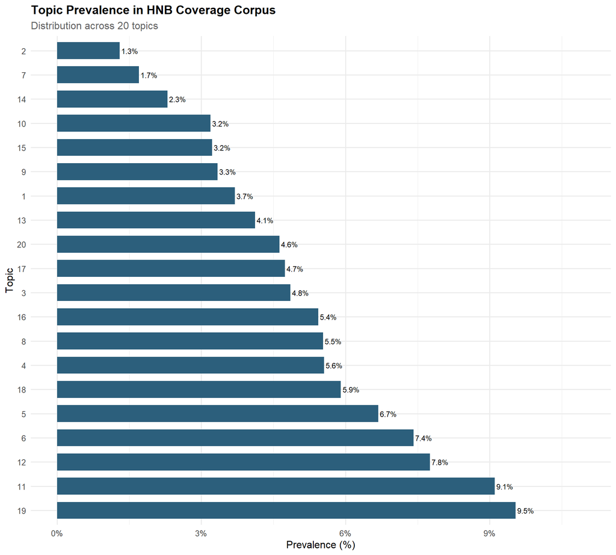

```r
topic_proportions <- colMeans(stm_model$theta)

topic_prev_df <- data.frame(
  Topic = factor(1:K),
  Prevalence = topic_proportions * 100
) %>%
  arrange(desc(Prevalence)) %>%
  mutate(Topic = factor(Topic, levels = Topic))

ggplot(topic_prev_df, aes(x = Topic, y = Prevalence)) +
  geom_col(fill = "#2c5f7c", width = 0.7) +
  geom_text(aes(label = sprintf("%.1f%%", Prevalence)),
            hjust = -0.1, size = 3) +
  coord_flip() +
  scale_y_continuous(limits = c(0, max(topic_prev_df$Prevalence) * 1.15),
                     labels = function(x) paste0(x, "%")) +
  labs(
    title = "Topic Prevalence in HNB Coverage Corpus",
    subtitle = paste("Distribution across", K, "topics"),
    x = "Topic",
    y = "Prevalence (%)"
  )
```

## 2.4 Topic Word Clouds

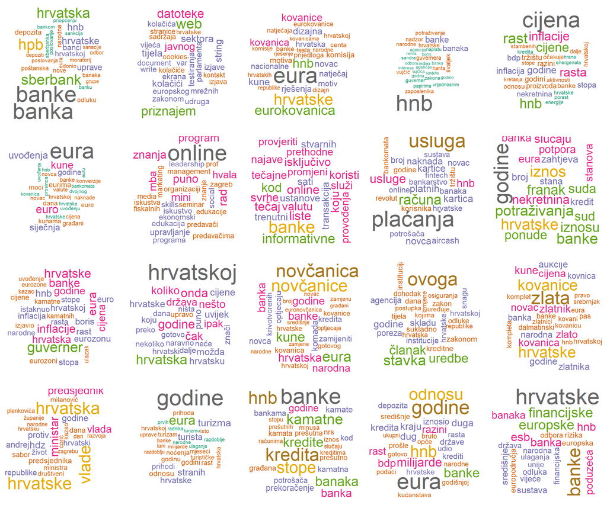

```r
n_rows <- ceiling(K / 5)
par(mfrow = c(n_rows, 5), mar = c(0.5, 0.5, 1.5, 0.5))

for (i in 1:K) {
  cloud(stm_model, topic = i, max.words = 30,
        colors = brewer.pal(8, "Dark2"),
        main = paste("Topic", i))
}
```

```r
par(mfrow = c(1, 1))
```

# 3 Analysis 2.2: Topic Taxonomy

Group discovered topics into higher order thematic categories based on keyword matching against predefined dictionaries for monetary policy and financial coverage.

## 3.1 Category Definitions

| Category | Description | Example keywords |
| --- | --- | --- |
| Monetary Policy | Central bank policy, interest rates, money supply | kamatna, monetarn, politika, referentn |
| Euro Transition | Currency conversion, eurozone accession | euro, konverzij, tečaj, tecaj, zamjen |
| Inflation/Prices | Price stability, inflation, cost of living | inflacij, cijene, poskupljenj, rast cijena |
| Banking Sector | Commercial banking, loans, deposits | kredit, banka, štednj, zajam |
| Economic Conditions | GDP, growth, employment, recession | gospodarstvo, rast, bdp, nezaposlen |
| Financial Regulation | Supervision, compliance, financial stability | nadzor, regulacij, stabilnost, propisi |
| Political/Institutional | Government policy, EU relations, political actors | vlada, sabor, eu, ministar |
| Consumer Finance | Personal finance, exchange, payments | mjenjačnic, plaćanj, transakcij |

```r
topic_taxonomy <- data.frame(
  Topic = 1:K,
  stringsAsFactors = FALSE
)

topic_taxonomy$Category <- NA
topic_taxonomy$Label <- NA

topic_words_list <- lapply(1:K, function(i) {
  c(topic_words$prob[i, ], topic_words$frex[i, ])
})

# KEYWORD DICTIONARIES FOR FINANCIAL/MONETARY POLICY CONTENT

monetary_policy_keywords <- c(
  "kamat", "kamatna", "kamatne", "kamatnih", "kamatnu",
  "monetarn", "monetarna", "monetarne", "monetarni",
  "politika", "politike", "politiku",
  "referentn", "referentna", "referentne",
  "stopa", "stope", "stopu", "stopom",
  "ecb", "europska središnja", "središnja banka",
  "likvidnost", "likvidnosti",
  "tržište", "trziste", "novčano", "novcano",
  "repo", "lombardn", "eskontna",
  "transmisij", "transmisijski"
)

euro_transition_keywords <- c(
  "euro", "eura", "eurom", "eur",
  "eurozon", "eurozona", "eurozone",
  "konverzij", "konverzija", "konverzije", "konverziju",
  "tečaj", "tecaj", "tečaja", "tecaja", "tečajn", "tecajn",
  "zamjen", "zamjena", "zamjene", "zamjenu",
  "uvođenj", "uvodjenje", "uvedeni", "uveden",
  "fiksn", "fiksni", "fiksnog", "fiksiran",
  "erm", "tečajni mehanizam", "tecajni mehanizam",
  "pristupanj", "pristupanje", "priključenj"
)

inflation_keywords <- c(
  "inflacij", "inflacija", "inflacije", "inflaciju", "inflacijski",
  "cijena", "cijene", "cijenama",
  "poskupljenj", "poskupljenje", "poskupljenja",
  "rast cijena", "pad cijena",
  "indeks potrošačkih", "indeks potrosackih",
  "skupoć", "skupoca", "životni standard", "zivotni standard",
  "energent", "energenata", "energetski",
  "hran", "hrana", "namirnic"
)

banking_sector_keywords <- c(
  "kredit", "kredita", "kredite", "kreditn", "kreditni", "kreditiranje",
  "banka", "banke", "bankama", "bankar", "bankarski",
  "štednj", "stednja", "štednje", "stednje", "štednju", "stednju",
  "zajam", "zajma", "zajmov",
  "depozit", "depozita", "depozite",
  "kamata na kredit", "stambeni kredit", "potrošački kredit",
  "hipotekar", "hipoteka",
  "odobreni kredit", "plasman"
)

economic_conditions_keywords <- c(
  "gospodars", "gospodarstvo", "gospodarstva", "gospodarski",
  "bdp", "bruto domaći", "bruto domaci",
  "rast", "rasta", "rastu", "rastom",
  "pad", "pada", "padu",
  "recesij", "recesija", "recesije",
  "oporavak", "oporavka",
  "nezaposlen", "nezaposlenost", "nezaposlenih",
  "zapošljavan", "zaposljavanje",
  "izvoz", "izvoza", "uvoz", "uvoza",
  "industrijska proizvodnja", "proizvodnj"
)

financial_regulation_keywords <- c(
  "nadzor", "nadzora", "nadzoru", "nadzorn",
  "regulacij", "regulacija", "regulacije", "regulatorn",
  "stabilnost", "stabilnosti", "financijska stabilnost",
  "propisi", "propisa", "propisima",
  "supervizij", "supervizija",
  "kapital", "kapitala", "adekvatnost",
  "rizik", "rizika", "rizike", "rizičn",
  "bonitet", "boniteta", "bonitetn",
  "compliance", "usklađenost", "uskladjenost"
)

political_keywords <- c(
  "vlada", "vlade", "vladi", "vladin",
  "sabor", "sabora", "saborski",
  "ministar", "ministra", "ministarstvo",
  "predsjednik", "predsjednika", "premijer",
  "hdz", "sdp", "politič", "politic", "stranka",
  "europska unija", "europske unije", "eu",
  "bruxelles", "brisel",
  "zakon", "zakona", "zakonu", "zakonski"
)

consumer_finance_keywords <- c(
  "mjenjačnic", "mjenjacnica", "mjenjačnice", "mjenjacnice",
  "plaćanj", "placanje", "plaćanja", "placanja",
  "transakcij", "transakcija", "transakcije",
  "kartic", "kartica", "kartice", "kartični",
  "bankomat", "bankomata",
  "građan", "gradjan", "građana", "gradjana", "potrošač", "potrosac",
  "račun", "racun", "računa", "racuna",
  "internetsko bankarstvo", "mobilno bankarstvo"
)

assign_category <- function(words, topic_num) {
  words_str <- tolower(paste(words, collapse = " "))

  scores <- c(
    "Monetary Policy" = sum(sapply(monetary_policy_keywords, function(k) grepl(k, words_str))),
    "Euro Transition" = sum(sapply(euro_transition_keywords, function(k) grepl(k, words_str))),
    "Inflation/Prices" = sum(sapply(inflation_keywords, function(k) grepl(k, words_str))),
    "Banking Sector" = sum(sapply(banking_sector_keywords, function(k) grepl(k, words_str))),
    "Economic Conditions" = sum(sapply(economic_conditions_keywords, function(k) grepl(k, words_str))),
    "Financial Regulation" = sum(sapply(financial_regulation_keywords, function(k) grepl(k, words_str))),
    "Political/Institutional" = sum(sapply(political_keywords, function(k) grepl(k, words_str))),
    "Consumer Finance" = sum(sapply(consumer_finance_keywords, function(k) grepl(k, words_str)))
  )

  if (max(scores) == 0) return("Other")

  max_score <- max(scores)
  winners <- names(scores[scores == max_score])

  priority <- c("Monetary Policy", "Euro Transition", "Inflation/Prices",
                "Banking Sector", "Financial Regulation", "Economic Conditions",
                "Political/Institutional", "Consumer Finance")

  for (p in priority) {
    if (p %in% winners) return(p)
  }

  return(winners[1])
}

for (i in 1:K) {
  topic_taxonomy$Category[i] <- assign_category(topic_words_list[[i]], i)
  top_frex <- topic_words$frex[i, 1:3]
  topic_taxonomy$Label[i] <- paste(top_frex, collapse = ", ")
}

topic_taxonomy %>%
  arrange(Category, Topic) %>%
  left_join(topic_prev_df %>% select(Topic, Prevalence) %>%
              mutate(Topic = as.numeric(as.character(Topic))), by = "Topic") %>%
  mutate(Prevalence = sprintf("%.2f%%", Prevalence)) %>%
  kable(col.names = c("Topic", "Category", "Top FREX Words", "Prevalence")) %>%
  kable_styling(bootstrap_options = c("striped", "hover"), full_width = FALSE) %>%
  scroll_box(height = "500px")
```

| Topic | Category | Top FREX Words | Prevalence |
| --- | --- | --- | --- |
| 1 | Banking Sector | sberbank, sberbanka, hpb | 3.70% |
| 4 | Banking Sector | trgovali, švaljek, trgovalo | 5.55% |
| 10 | Banking Sector | zemljišta, građenja, vrhovnog | 3.19% |
| 18 | Banking Sector | prešutna, prešutnih, prekoračenja | 5.90% |
| 9 | Consumer Finance | aircash, revolut, mastercard | 3.34% |
| 3 | Euro Transition | tesle, glagoljica, šahovnica | 4.85% |
| 6 | Euro Transition | dvojnog, dvojno, preračunavanje | 7.41% |
| 8 | Euro Transition | informativne, jamčiti, konverter | 5.53% |
| 11 | Euro Transition | eurozoni, dombrovskis, eurozonu | 9.10% |
| 13 | Euro Transition | krivotvorenih, novčanicu, krivotvorina | 4.12% |
| 17 | Euro Transition | noćenja, brnjac, turista | 4.74% |
| 19 | Euro Transition | porasli, dug, iznosio | 9.54% |
| 20 | Euro Transition | pismenosti, mmf, klimatskih | 4.63% |
| 5 | Inflation/Prices | producer, industrial, domestic | 6.68% |
| 15 | Inflation/Prices | zlata, zlatnik, zlato | 3.23% |
| 2 | Other | priznajem, string, var | 1.30% |
| 7 | Other | mba, skills, leadership | 1.70% |
| 12 | Other | previše, novotny, faz | 7.76% |
| 14 | Political/Institutional | stavka, ovoga, članka | 2.30% |
| 16 | Political/Institutional | žalac, križevačke, penava | 5.43% |

## 3.2 Category Distribution

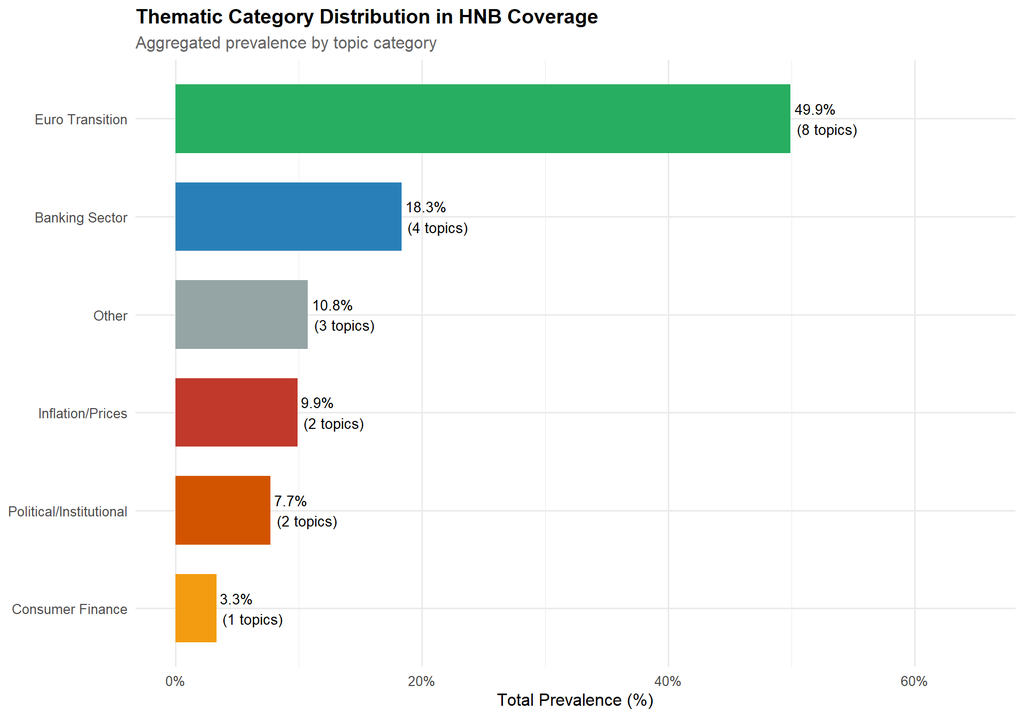

```r
category_prevalence <- topic_taxonomy %>%
  left_join(topic_prev_df %>%
              mutate(Topic = as.numeric(as.character(Topic))), by = "Topic") %>%
  group_by(Category) %>%
  summarise(
    Topics = n(),
    Total_Prevalence = sum(Prevalence, na.rm = TRUE),
    .groups = "drop"
  ) %>%
  arrange(desc(Total_Prevalence))

ggplot(category_prevalence, aes(x = reorder(Category, Total_Prevalence),
                                y = Total_Prevalence, fill = Category)) +
  geom_col(width = 0.7) +
  geom_text(aes(label = sprintf("%.1f%%\n(%d topics)", Total_Prevalence, Topics)),
            hjust = -0.1, size = 3.5) +
  coord_flip() +
  scale_fill_manual(values = topic_category_colors) +
  scale_y_continuous(limits = c(0, max(category_prevalence$Total_Prevalence) * 1.3),
                     labels = function(x) paste0(x, "%")) +
  labs(
    title = "Thematic Category Distribution in HNB Coverage",
    subtitle = "Aggregated prevalence by topic category",
    x = NULL,
    y = "Total Prevalence (%)"
  ) +
  theme(legend.position = "none")
```

# 4 Analysis 2.3: Topic by Actor Mapping

Examine how different actor types specialize in particular topics.

## 4.1 Understanding Actor Topic Relationships

Different actors in central bank coverage have distinct communication priorities. HNB Official sources may focus on policy announcements, while media may emphasize consumer impact and political angles.

**Lift interpretation:**

- **Lift = 1.0:** Actor discusses this topic at the same rate as overall corpus
- **Lift > 1.0:** Actor specializes in this topic
- **Lift < 1.0:** Actor underrepresents this topic

```r
doc_topics <- stm_model$theta
colnames(doc_topics) <- paste0("Topic_", 1:K)

doc_meta <- stm_dfm$meta
doc_meta <- cbind(doc_meta, doc_topics)

actor_topic_means <- doc_meta %>%
  group_by(actor_type) %>%
  summarise(across(starts_with("Topic_"), mean, na.rm = TRUE), .groups = "drop")

actor_topic_long <- actor_topic_means %>%
  pivot_longer(cols = starts_with("Topic_"),
               names_to = "Topic",
               values_to = "Proportion") %>%
  mutate(Topic_Num = as.numeric(gsub("Topic_", "", Topic)))
```

## 4.2 Topic Proportions by Actor Type Heatmap

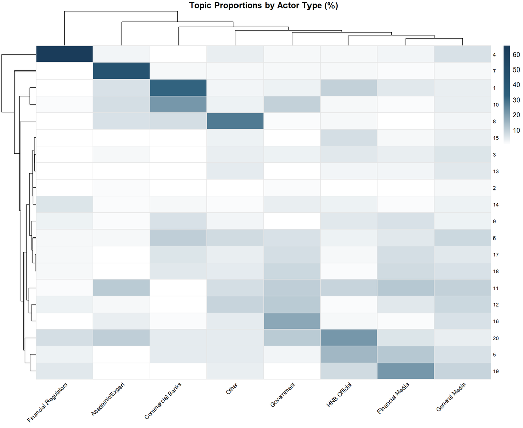

```r
actor_topic_matrix <- actor_topic_means %>%
  column_to_rownames("actor_type") %>%
  as.matrix()

colnames(actor_topic_matrix) <- 1:K

pheatmap(
  t(actor_topic_matrix) * 100,
  cluster_rows = TRUE,
  cluster_cols = TRUE,
  color = colorRampPalette(c("white", "#2c5f7c", "#1a3c5a"))(100),
  main = "Topic Proportions by Actor Type (%)",
  fontsize = 10,
  fontsize_row = 8,
  fontsize_col = 9,
  angle_col = 45,
  display_numbers = FALSE,
  border_color = "grey90"
)
```

## 4.3 Actor Specialization Index

Top 3 topics where each actor type most strongly overindexes.

```r
corpus_avg <- colMeans(doc_topics)

specialization_df <- actor_topic_long %>%
  left_join(tibble(Topic_Num = 1:K, Corpus_Avg = corpus_avg), by = "Topic_Num") %>%
  mutate(
    Lift = Proportion / Corpus_Avg,
    Log_Lift = log2(Lift)
  ) %>%
  left_join(topic_taxonomy %>% select(Topic, Category, Label) %>%
              rename(Topic_Num = Topic), by = "Topic_Num")

top_specializations <- specialization_df %>%
  filter(is.finite(Log_Lift)) %>%
  group_by(actor_type) %>%
  slice_max(Log_Lift, n = 3) %>%
  ungroup()

top_specializations %>%
  select(actor_type, Label, Category, Lift) %>%
  mutate(Lift = sprintf("%.2fx", Lift)) %>%
  arrange(actor_type) %>%
  kable(col.names = c("Actor Type", "Topic", "Category", "Lift vs Corpus")) %>%
  kable_styling(bootstrap_options = c("striped", "hover"), full_width = FALSE) %>%
  scroll_box(height = "400px")
```

| Actor Type | Topic | Category | Lift vs Corpus |
| --- | --- | --- | --- |
| HNB Official | pismenosti, mmf, klimatskih | Euro Transition | 4.58x |
| HNB Official | sberbank, sberbanka, hpb | Banking Sector | 2.49x |
| HNB Official | producer, industrial, domestic | Inflation/Prices | 2.24x |
| Financial Regulators | trgovali, švaljek, trgovalo | Banking Sector | 11.77x |
| Financial Regulators | stavka, ovoga, članka | Political/Institutional | 2.52x |
| Financial Regulators | pismenosti, mmf, klimatskih | Euro Transition | 1.47x |
| Government | žalac, križevačke, penava | Political/Institutional | 3.33x |
| Government | zemljišta, građenja, vrhovnog | Banking Sector | 3.06x |
| Government | pismenosti, mmf, klimatskih | Euro Transition | 2.28x |
| Commercial Banks | sberbank, sberbanka, hpb | Banking Sector | 8.52x |
| Commercial Banks | zemljišta, građenja, vrhovnog | Banking Sector | 6.72x |
| Commercial Banks | aircash, revolut, mastercard | Consumer Finance | 1.87x |
| Financial Media | porasli, dug, iznosio | Euro Transition | 2.20x |
| Financial Media | aircash, revolut, mastercard | Consumer Finance | 1.80x |
| Financial Media | producer, industrial, domestic | Inflation/Prices | 1.67x |
| General Media | priznajem, string, var | Other | 1.32x |
| General Media | stavka, ovoga, članka | Political/Institutional | 1.16x |
| General Media | žalac, križevačke, penava | Political/Institutional | 1.14x |
| Academic/Expert | mba, skills, leadership | Other | 25.51x |
| Academic/Expert | zemljišta, građenja, vrhovnog | Banking Sector | 2.21x |
| Academic/Expert | pismenosti, mmf, klimatskih | Euro Transition | 2.18x |
| Other | informativne, jamčiti, konverter | Euro Transition | 4.86x |
| Other | previše, novotny, faz | Other | 1.11x |
| Other | krivotvorenih, novčanicu, krivotvorina | Euro Transition | 1.01x |

## 4.4 Actor Type Category Profiles

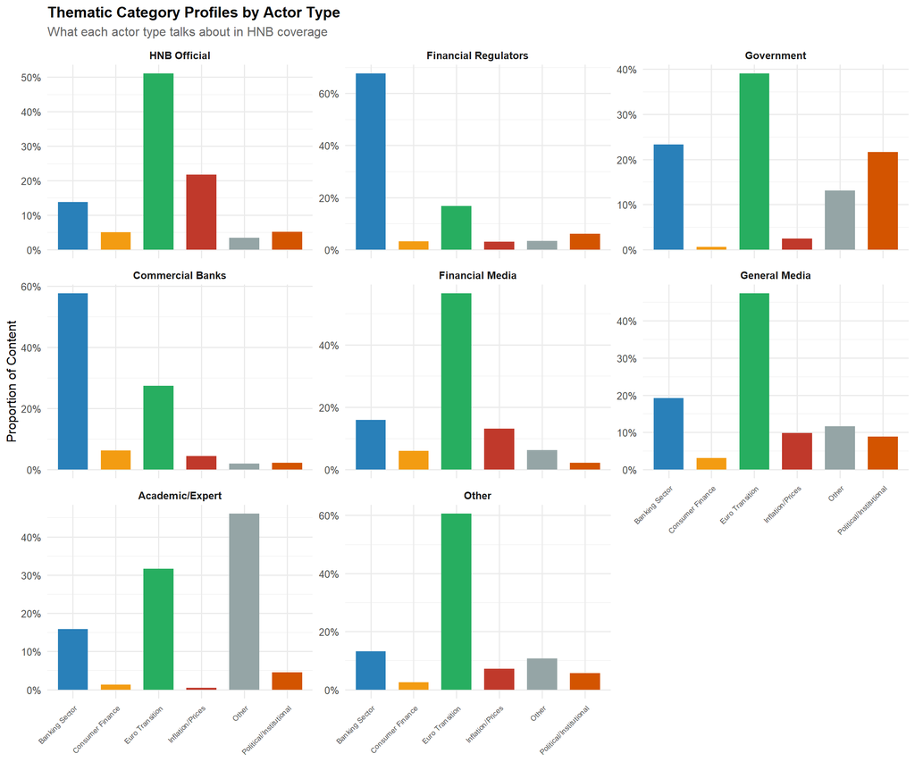

```r
category_by_actor <- specialization_df %>%
  group_by(actor_type, Category) %>%
  summarise(Category_Proportion = sum(Proportion), .groups = "drop")

ggplot(category_by_actor, aes(x = Category, y = Category_Proportion, fill = Category)) +
  geom_col(width = 0.7) +
  facet_wrap(~actor_type, scales = "free_y", ncol = 3) +
  scale_fill_manual(values = topic_category_colors) +
  scale_y_continuous(labels = function(x) paste0(round(x * 100, 1), "%")) +
  labs(
    title = "Thematic Category Profiles by Actor Type",
    subtitle = "What each actor type talks about in HNB coverage",
    x = NULL,
    y = "Proportion of Content"
  ) +
  theme(
    axis.text.x = element_text(angle = 45, hjust = 1, size = 7),
    legend.position = "none",
    strip.text = element_text(face = "bold")
  )
```

# 5 Analysis 2.4: Topic by Period Mapping

How did topics shift with euro adoption?

```r
period_topic_means <- doc_meta %>%
  group_by(period) %>%
  summarise(across(starts_with("Topic_"), mean, na.rm = TRUE), .groups = "drop")

period_topic_long <- period_topic_means %>%
  pivot_longer(cols = starts_with("Topic_"),
               names_to = "Topic",
               values_to = "Proportion") %>%
  mutate(Topic_Num = as.numeric(gsub("Topic_", "", Topic))) %>%
  left_join(topic_taxonomy %>% select(Topic, Category, Label) %>%
              rename(Topic_Num = Topic), by = "Topic_Num")
```

## 5.1 Topic Shift: ERM II to Euro Era

```r
period_wide <- period_topic_long %>%
  select(period, Topic_Num, Proportion, Label) %>%
  pivot_wider(names_from = period, values_from = Proportion) %>%
  mutate(
    Change = `Euro Era` - `ERM II`,
    Pct_Change = Change / `ERM II` * 100
  ) %>%
  arrange(desc(abs(Change)))

period_wide %>%
  head(15) %>%
  mutate(
    `ERM II` = sprintf("%.1f%%", `ERM II` * 100),
    `Euro Era` = sprintf("%.1f%%", `Euro Era` * 100),
    Change = sprintf("%+.1f pp", Change * 100)
  ) %>%
  kable(col.names = c("Topic", "Label", "ERM II", "Euro Era", "Change", "% Change")) %>%
  kable_styling(bootstrap_options = c("striped", "hover"), full_width = FALSE)
```

| Topic | Label | ERM II | Euro Era | Change | % Change |
| --- | --- | --- | --- | --- | --- |
| 8 | informativne, jamčiti, konverter | 7.1% | 1.7% | -5.4 pp | -76.086439 |
| 3 | tesle, glagoljica, šahovnica | 6.3% | 1.2% | -5.1 pp | -81.312814 |
| 13 | krivotvorenih, novčanicu, krivotvorina | 2.8% | 7.5% | +4.7 pp | 167.838616 |
| 4 | trgovali, švaljek, trgovalo | 6.6% | 2.9% | -3.7 pp | -55.952503 |
| 17 | noćenja, brnjac, turista | 3.7% | 7.3% | +3.6 pp | 95.347826 |
| 11 | eurozoni, dombrovskis, eurozonu | 8.2% | 11.4% | +3.3 pp | 40.108938 |
| 5 | producer, industrial, domestic | 5.9% | 8.6% | +2.7 pp | 45.079704 |
| 16 | žalac, križevačke, penava | 6.0% | 3.9% | -2.1 pp | -35.315561 |
| 1 | sberbank, sberbanka, hpb | 4.2% | 2.3% | -1.9 pp | -44.752118 |
| 14 | stavka, ovoga, članka | 1.8% | 3.5% | +1.7 pp | 90.887323 |
| 12 | previše, novotny, faz | 7.3% | 8.9% | +1.6 pp | 21.456829 |
| 18 | prešutna, prešutnih, prekoračenja | 6.3% | 5.0% | -1.3 pp | -20.282050 |
| 15 | zlata, zlatnik, zlato | 2.9% | 4.0% | +1.1 pp | 37.692624 |
| 20 | pismenosti, mmf, klimatskih | 4.4% | 5.2% | +0.9 pp | 19.868130 |
| 19 | porasli, dug, iznosio | 9.6% | 9.4% | -0.2 pp | -2.098904 |

## 5.2 Category Distribution by Period

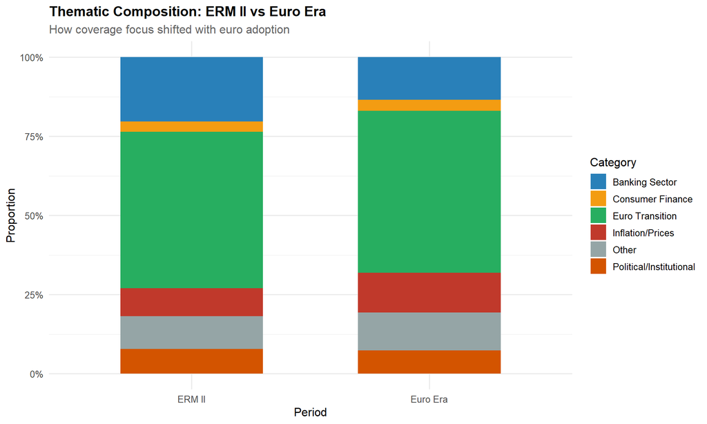

```r
category_by_period <- period_topic_long %>%
  group_by(period, Category) %>%
  summarise(Category_Proportion = sum(Proportion), .groups = "drop")

ggplot(category_by_period, aes(x = period, y = Category_Proportion, fill = Category)) +
  geom_col(position = "fill", width = 0.6) +
  scale_fill_manual(values = topic_category_colors) +
  scale_y_continuous(labels = percent) +
  labs(
    title = "Thematic Composition: ERM II vs Euro Era",
    subtitle = "How coverage focus shifted with euro adoption",
    x = "Period",
    y = "Proportion",
    fill = "Category"
  ) +
  theme(legend.position = "right")
```

# 6 Analysis 2.5: Topic Attention Differential

Which topics generate more attention (REACH)?

This analysis addresses a key hypothesis: that certain types of content generate disproportionately high attention compared to their prevalence.

```r
# Get REACH values aligned with the sampled documents
doc_reach_vec <- hnb_sample$REACH

# Add REACH directly to doc_meta
doc_meta_reach <- doc_meta
doc_meta_reach$REACH <- doc_reach_vec[1:nrow(doc_meta)]

# Calculate topic-level REACH metrics
topic_reach <- lapply(1:K, function(t) {
  topic_col <- paste0("Topic_", t)
  weights <- doc_meta_reach[[topic_col]]
  reach_vals <- doc_meta_reach$REACH

  data.frame(
    Topic = t,
    Weighted_Mean_REACH = weighted.mean(reach_vals, weights, na.rm = TRUE),
    Mean_REACH = mean(reach_vals[weights > 0.1], na.rm = TRUE),
    Total_REACH = sum(reach_vals * weights, na.rm = TRUE),
    Document_Count = sum(weights > 0.1)
  )
}) %>% bind_rows()

topic_reach <- topic_reach %>%
  left_join(topic_taxonomy, by = "Topic") %>%
  left_join(topic_prev_df %>%
              mutate(Topic = as.numeric(as.character(Topic))), by = "Topic")
```

## 6.1 Topic REACH Ranking

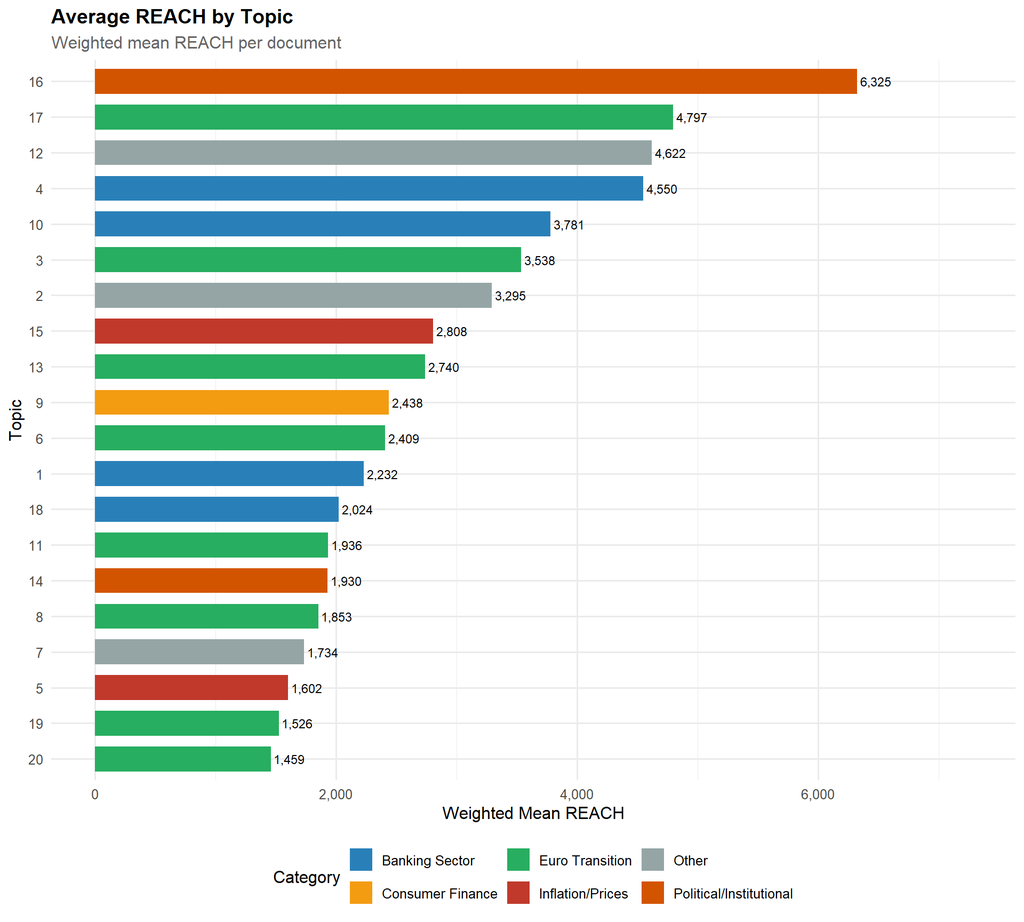

```r
ggplot(topic_reach, aes(x = reorder(factor(Topic), Weighted_Mean_REACH),
                        y = Weighted_Mean_REACH, fill = Category)) +
  geom_col(width = 0.7) +
  geom_text(aes(label = format(round(Weighted_Mean_REACH, 0), big.mark = ",")),
            hjust = -0.1, size = 3) +
  coord_flip() +
  scale_fill_manual(values = topic_category_colors) +
  scale_y_continuous(limits = c(0, max(topic_reach$Weighted_Mean_REACH, na.rm = TRUE) * 1.15),
                     labels = comma) +
  labs(
    title = "Average REACH by Topic",
    subtitle = "Weighted mean REACH per document",
    x = "Topic",
    y = "Weighted Mean REACH",
    fill = "Category"
  )
```

## 6.2 Volume vs Attention Comparison

Topics above the trend line generate more attention than expected given their prevalence.

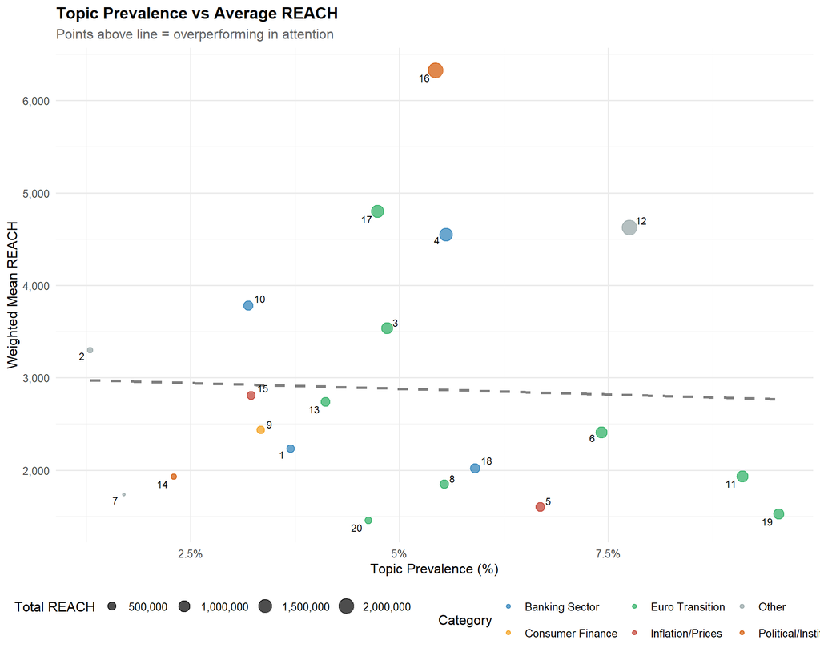

```r
ggplot(topic_reach, aes(x = Prevalence, y = Weighted_Mean_REACH)) +
  geom_point(aes(color = Category, size = Total_REACH), alpha = 0.7) +
  geom_smooth(method = "lm", se = FALSE, linetype = "dashed", color = "gray50") +
  geom_text_repel(aes(label = Topic), size = 3, max.overlaps = 15) +
  scale_color_manual(values = topic_category_colors) +
  scale_size_continuous(labels = comma, name = "Total REACH") +
  scale_x_continuous(labels = function(x) paste0(x, "%")) +
  scale_y_continuous(labels = comma) +
  labs(
    title = "Topic Prevalence vs Average REACH",
    subtitle = "Points above line = overperforming in attention",
    x = "Topic Prevalence (%)",
    y = "Weighted Mean REACH",
    color = "Category"
  )
```

## 6.3 Category REACH Comparison

```r
category_reach <- topic_reach %>%
  group_by(Category) %>%
  summarise(
    Topics = n(),
    Total_Prevalence = sum(Prevalence, na.rm = TRUE),
    Mean_REACH = weighted.mean(Weighted_Mean_REACH, Prevalence, na.rm = TRUE),
    Total_REACH = sum(Total_REACH, na.rm = TRUE),
    .groups = "drop"
  ) %>%
  mutate(
    REACH_Share = Total_REACH / sum(Total_REACH) * 100,
    Efficiency = REACH_Share / Total_Prevalence
  )

category_reach %>%
  arrange(desc(Efficiency)) %>%
  mutate(
    Total_Prevalence = sprintf("%.1f%%", Total_Prevalence),
    REACH_Share = sprintf("%.1f%%", REACH_Share),
    Mean_REACH = format(round(Mean_REACH, 0), big.mark = ","),
    Efficiency = sprintf("%.2fx", Efficiency)
  ) %>%
  kable(col.names = c("Category", "Topics", "Prevalence", "Mean REACH",
                      "Total REACH", "REACH Share", "Efficiency")) %>%
  kable_styling(bootstrap_options = c("striped", "hover"), full_width = FALSE)
```

| Category | Topics | Prevalence | Mean REACH | Total REACH | REACH Share | Efficiency |
| --- | --- | --- | --- | --- | --- | --- |
| Political/Institutional | 2 | 7.7% | 5,019 | 2193881.1 | 13.6% | 1.75x |
| Other | 3 | 10.8% | 4,005 | 2414413.3 | 14.9% | 1.39x |
| Banking Sector | 4 | 18.3% | 3,136 | 3257326.8 | 20.1% | 1.10x |
| Consumer Finance | 1 | 3.3% | 2,438 | 464287.7 | 2.9% | 0.86x |
| Euro Transition | 8 | 49.9% | 2,368 | 6724758.1 | 41.6% | 0.83x |
| Inflation/Prices | 2 | 9.9% | 1,995 | 1129675.0 | 7.0% | 0.70x |

# 7 Summary and Key Findings

```r
top_category <- category_prevalence %>%
  slice_max(Total_Prevalence, n = 1)
top_cat_name <- top_category$Category[1]
top_cat_prev <- round(top_category$Total_Prevalence[1], 1)

top_reach_cat <- category_reach %>%
  slice_max(Mean_REACH, n = 1)
top_reach_name <- top_reach_cat$Category[1]
```

## 7.2 Hypotheses Assessment

[output not shown]

# 8 Appendix: Model Diagnostics

```r
cat("Topic Model Summary:\n")
```

```
Topic Model Summary:
```

```r
cat("Number of topics:", K, "\n")
```

```
Number of topics: 20
```

```r
cat("Documents:", nrow(doc_topics), "\n")
```

```
Documents: 5737
```

```r
cat("Vocabulary size:", length(stm_model$vocab), "\n")
```

```
Vocabulary size: 21889
```

```r
cat("Sample percentage:", SAMPLE_PCT * 100, "%\n")
```

```
Sample percentage: 30 %
```